# Taller Evaluable 1 2020, FIFA 2019

3/12/2020

# 1 Taller evaluable datos FIFA 2020

Registraros en kaggle y bajaros el data set [FIFA 2020 Datos completos 2015 a 2020](https://www.kaggle.com/stefanoleone992/fifa-20-complete-player-dataset). Guarda los datos en una carpeta FIFA2020.

Las siguientes preguntas son relativas al data set `players_20.csv`.

Hay que contestar con código R explicar muy brevemente cada salida. Subid a la activada el Rmd y el html.

Este grupo de entrega será el mismo grupo de 3 que el proyecto final.

Rellenad estos datos:

**PONED NOMBRE DEL GRUPO**

- Apellidos, Nombre Alumno 1
- Apellidos, Nombre Alumno 2
- Apellidos, Nombre Alumno 3

## 1.1 Pregunta 0

Explica el data set y de qué tipo son cada una de las variables y en qué tipo de fichero están guardadas. Carga los datos en un data frame con `read.csv` y explica las clases de cada columna de datos. Explica el parámetro `encoding`. Es un data frame de 18278 observaciones (filas) y 104 variables (columna)

### 1.1.1 Solución

```r
datos = read.csv("FIFA2020/players_20.csv",
  encoding="UTF-8")# cambia tu path
#str(datos)
#names(datos)
```

Las variables de la 1 (`sofifa_id`) a la 31(`nation_jersey_number`) son variables de perfil del jugador: su nombre, su equipo su sueldo su número de camiseta… El resto de variables de la 32 (`pace`) a la 104 (`rb`) son variables numéricas enteras con valores de 0 a 100 que parametrizan cómo es el jugador el el juego FIFA player 2020

## 1.2 Pregunta 1

¿Qué 6 clubs tienen a los 10 mejores jugadores según la variable “shooting”?

### 1.2.1 Solución

La solución más adecuada es escoger los 10 mejores primeros jugadores por la variable `shooting` los 6 primeros clubs. Pero como pueden el Barça tiene dos juradores entre los 10 primeros hay que tomar los 6 mejores entre los clubs de los 10 mejores jugadores en `shooting` sin repetir; eso lo conseguimos con la función `unique` o simplemente construyendo la lista ala vista de los clubs de de los 10 mejores jugadores por `shooting` .

Se dará por correcta cualquier combinación de 6 clubs entre los clubs de los 10 mejores jugadores por tiro a puerta `shooting`.

```r
datos_o=datos[order(datos$shooting,decreasing=TRUE),]
datos_o$shooting[1:10]
```

```
##  [1] 93 92 91 90 89 89 88 88 87 87
```

```r
datos_o$long_name[1:10]
```

```
##  [1] Cristiano Ronaldo dos Santos Aveiro Lionel Andrés Messi Cuccittini
##  [3] Harry Kane                          Sergio Leonel Agüero del Castillo
##  [5] Luis Alberto Suárez Díaz            Fabio Quagliarella
##  [7] Marco Reus                          Zlatan Ibrahimovic
##  [9] Robert Lewandowski                  Gareth Frank Bale
## 18218 Levels: Ștefan Blanaru Ștefan Fara Ștefan Rusu ... Zymer Bytyqi
```

```r
datos_o$club[1:10]
```

```
##  [1] Juventus          FC Barcelona      Tottenham Hotspur Manchester City
##  [5] FC Barcelona      Sampdoria         Borussia Dortmund LA Galaxy
##  [9] FC Bayern München Real Madrid
## 698 Levels:  SSV Jahn Regensburg 1. FC Heidenheim 1846 ... Zaglebie Lubin
```

```r
unique(datos_o$club)[1:10]
```

```
##  [1] Juventus          FC Barcelona      Tottenham Hotspur Manchester City
##  [5] Sampdoria         Borussia Dortmund LA Galaxy         FC Bayern München
##  [9] Real Madrid       Liverpool
## 698 Levels:  SSV Jahn Regensburg 1. FC Heidenheim 1846 ... Zaglebie Lubin
```

```r
club6 = unique(datos_o$club)[1:6]# así sacamos os 6 clubs o simplemente construyendo la lista
club6
```

```
## [1] Juventus          FC Barcelona      Tottenham Hotspur Manchester City
## [5] Sampdoria         Borussia Dortmund
## 698 Levels:  SSV Jahn Regensburg 1. FC Heidenheim 1846 ... Zaglebie Lubin
```

Notad que guardamos los nombres de los 6 clubs en la variable `club6`.

## 1.3 Pregunta 2

Crea un data frame `fifa20_best_shooting` que contenga a TODOS los jugadores de los clubs encontrados en el ejercicio anterior.

### 1.3.1 Solución

Construimos el data frame `fifa20_best_shooting` utilizando la función `%in%` (estaba en el ejemplo de solución del profesor del FIFA 2019). Se admite cualquier otra solución correcta.

```r
fifa20_best_shooting=datos[datos$club %in% club6,]
unique(fifa20_best_shooting$club)
```

```
##  [1] FC Barcelona      Juventus          Real Madrid       Manchester City
##  [5] Liverpool         Tottenham Hotspur FC Bayern München Borussia Dortmund
##  [9] LA Galaxy         Sampdoria
## 698 Levels:  SSV Jahn Regensburg 1. FC Heidenheim 1846 ... Zaglebie Lubin
```

## 1.4 Pregunta 3

Calcular la media y la desviación típica del sueldo de cada equipo del data frame `fifa20_best_shooting`.

### 1.4.1 Solución

Es una caso típico de uso de la función `aggregate` (es una función clásica) está en el [capítulo de data frames de AprendeR1](https://aprender-uib.github.io/AprendeR1/chap-df.html).

```r
aggregate(wage_eur~club, data=fifa20_best_shooting,
          FUN=function(x){c(media=mean(x),
                            desv.tip=sd(x),
                            mínimo=min(x),
                            máximo=max(x))})
```

```
##                 club wage_eur.media wage_eur.desv.tip wage_eur.mínimo
## 1  Borussia Dortmund      57806.452         43276.953        1000.000
## 2       FC Barcelona     150000.000        130914.810       12000.000
## 3  FC Bayern München     109391.304         57908.815        7000.000
## 4           Juventus     113636.364         77462.418       17000.000
## 5          LA Galaxy       4185.185          3731.746        1000.000
## 6          Liverpool      80818.182         67478.911        1000.000
## 7    Manchester City     120727.273         99257.013        1000.000
## 8        Real Madrid     162242.424        111794.463        6000.000
## 9          Sampdoria      18781.250         11686.039        3000.000
## 10 Tottenham Hotspur      78878.788         60960.416        1000.000
##    wage_eur.máximo
## 1       170000.000
## 2       565000.000
## 3       235000.000
## 4       405000.000
## 5        15000.000
## 6       240000.000
## 7       370000.000
## 8       470000.000
## 9        46000.000
## 10      220000.000
```

## 1.5 Pregunta 4

Discretiza la variable `age` de `fifa20_best_shooting` en los 3 niveles siguientes: “freshman”, “junior”, “senior”, según los cortes por defecto. La variable resultante age_Level tiene que ser un factor ordenado en orden creciente de edad.

### 1.5.1 Solución

En el tema [Datos cuantitativos agrupados de AprendeR1](https://aprender-uib.github.io/AprendeR1/chap-hist.html) se explica como agrupar variables continuas por intervalos. En este caso nos piden la solución por defecto de la función `cut`en 3 `breaks` y luego hay que transformarla a un factor ordenado con los `levels` “freshman”, “junior”, “senior”.

```r
age3=ordered(cut(fifa20_best_shooting$age,breaks=3))# corto en tres  partes
fifa20_best_shooting$age[1:3]
```

```
## [1] 32 34 28
```

```r
head(age3)
```

```
## [1] (25,33] (33,41] (25,33] (25,33] (25,33] (25,33]
## Levels: (17,25] < (25,33] < (33,41]
```

```r
class(age3)
```

```
## [1] "ordered" "factor"
```

```r
str(age3)
```

```
##  Ord.factor w/ 3 levels "(17,25]"<"(25,33]"<..: 2 3 2 2 2 2 2 2 1 2 ...
```

```r
levels(age3)<- c("freshman", "junior", "senior")
table(age3)
```

```
## age3
## freshman   junior   senior
##      176      125       10
```

## 1.6 Pregunta 5

¿Qué club tiene a más jugadores en el nivel “senior” calculado en el ejercicio anterior?

### 1.6.1 Solución

```r
table(droplevels(fifa20_best_shooting$club),age3)
```

```
##                    age3
##                     freshman junior senior
##   Borussia Dortmund       20     10      1
##   FC Barcelona            21     12      0
##   FC Bayern München       13     10      0
##   Juventus                14     16      3
##   LA Galaxy                9     17      1
##   Liverpool               18     14      1
##   Manchester City         23      8      2
##   Real Madrid             16     17      0
##   Sampdoria               22      8      2
##   Tottenham Hotspur       20     13      0
```

Es el Juventus con 3 jugadores `senior`. Notad que utilizamos la función `droplevels` para eliminar niveles de la variable club que no aparecen en el data frame `fifa20_best_shooting`.

## 1.7 Pregunta 6

¿Cuántas nacionalidades hay entre todos los jugadores de `fifa20_best_shooting`? ¿Qué club tiene mayor cantidad de nacionalidades?

### 1.7.1 Solución

```r
length(levels(fifa20_best_shooting$nationality))
```

```
## [1] 162
```

```r
length(levels(fifa20_best_shooting$nationality))
```

```
## [1] 162
```

```r
length(unique(droplevels(fifa20_best_shooting$nationality)))
```

```
## [1] 48
```

Ahora contar las nacionalidades por club es un poco más delicado. Podemos hacer la tabla de nacionalidades por club (como siempre con el `droplevels`)

```r
knitr::kable(
  t(table(droplevels(
    fifa20_best_shooting$club),
          droplevels(
            fifa20_best_shooting$nationality)
    )
    ))# notad que transpongo la tabla
```

|  | Borussia Dortmund | FC Barcelona | FC Bayern München | Juventus | LA Galaxy | Liverpool | Manchester City | Real Madrid | Sampdoria | Tottenham Hotspur |
| --- | --- | --- | --- | --- | --- | --- | --- | --- | --- | --- |
| Algeria | 0 | 0 | 0 | 0 | 0 | 1 | 1 | 0 | 0 | 0 |
| Argentina | 1 | 1 | 0 | 2 | 3 | 0 | 3 | 0 | 1 | 4 |
| Austria | 0 | 0 | 1 | 0 | 0 | 0 | 0 | 0 | 0 | 0 |
| Belgium | 2 | 0 | 0 | 0 | 0 | 1 | 1 | 2 | 0 | 2 |
| Bosnia Herzegovina | 0 | 0 | 0 | 1 | 0 | 0 | 0 | 0 | 0 | 0 |
| Brazil | 0 | 3 | 1 | 4 | 1 | 3 | 3 | 6 | 0 | 1 |
| Cameroon | 0 | 0 | 0 | 0 | 0 | 1 | 0 | 0 | 0 | 0 |
| Canada | 0 | 0 | 1 | 0 | 0 | 0 | 0 | 0 | 0 | 0 |
| Chile | 0 | 1 | 0 | 0 | 0 | 0 | 1 | 0 | 0 | 0 |
| Colombia | 0 | 0 | 0 | 1 | 0 | 0 | 0 | 1 | 1 | 1 |
| Costa Rica | 0 | 0 | 0 | 0 | 1 | 0 | 0 | 1 | 0 | 0 |
| Croatia | 0 | 1 | 1 | 2 | 0 | 1 | 0 | 1 | 0 | 0 |
| Cyprus | 0 | 0 | 0 | 0 | 0 | 0 | 0 | 0 | 0 | 2 |
| Czech Republic | 0 | 0 | 0 | 0 | 0 | 0 | 0 | 0 | 1 | 0 |
| Denmark | 2 | 0 | 0 | 0 | 0 | 0 | 0 | 0 | 0 | 1 |
| Dominican Republic | 0 | 0 | 0 | 0 | 0 | 0 | 0 | 1 | 0 | 0 |
| Egypt | 0 | 0 | 0 | 0 | 0 | 1 | 0 | 0 | 0 | 0 |
| England | 1 | 0 | 0 | 0 | 0 | 13 | 8 | 0 | 1 | 13 |
| France | 2 | 5 | 5 | 3 | 2 | 0 | 3 | 3 | 2 | 4 |
| Gambia | 0 | 0 | 0 | 0 | 0 | 0 | 0 | 0 | 1 | 0 |
| Germany | 15 | 1 | 10 | 2 | 0 | 1 | 2 | 1 | 1 | 0 |
| Guinea | 0 | 0 | 0 | 0 | 0 | 1 | 0 | 0 | 0 | 0 |
| Italy | 0 | 0 | 0 | 12 | 0 | 0 | 0 | 0 | 17 | 0 |
| Ivory Coast | 0 | 0 | 0 | 0 | 0 | 0 | 0 | 0 | 0 | 1 |
| Japan | 0 | 1 | 0 | 0 | 0 | 0 | 0 | 1 | 0 | 0 |
| Kenya | 0 | 0 | 0 | 0 | 0 | 0 | 0 | 0 | 0 | 1 |
| Korea Republic | 0 | 0 | 0 | 0 | 0 | 0 | 0 | 0 | 0 | 1 |
| Mexico | 0 | 0 | 0 | 0 | 3 | 0 | 0 | 0 | 0 | 0 |
| Montenegro | 0 | 0 | 0 | 0 | 0 | 0 | 0 | 0 | 1 | 0 |
| Morocco | 1 | 0 | 0 | 0 | 0 | 0 | 0 | 0 | 0 | 0 |
| Netherlands | 0 | 2 | 0 | 1 | 0 | 4 | 0 | 0 | 0 | 0 |
| Norway | 0 | 0 | 0 | 0 | 1 | 0 | 0 | 0 | 1 | 0 |
| Paraguay | 0 | 0 | 0 | 0 | 0 | 0 | 0 | 0 | 1 | 0 |
| Poland | 1 | 0 | 1 | 1 | 0 | 0 | 0 | 0 | 2 | 0 |
| Portugal | 1 | 1 | 1 | 1 | 0 | 0 | 2 | 0 | 0 | 0 |
| Republic of Ireland | 0 | 0 | 0 | 0 | 0 | 1 | 2 | 0 | 0 | 1 |
| Scotland | 0 | 0 | 0 | 0 | 0 | 1 | 0 | 0 | 0 | 0 |
| Senegal | 0 | 1 | 0 | 0 | 0 | 1 | 0 | 0 | 0 | 0 |
| Serbia | 0 | 0 | 0 | 0 | 0 | 0 | 0 | 1 | 0 | 0 |
| Spain | 2 | 15 | 2 | 0 | 0 | 2 | 5 | 13 | 0 | 0 |
| Sweden | 0 | 0 | 0 | 0 | 1 | 0 | 0 | 0 | 1 | 0 |
| Switzerland | 3 | 0 | 0 | 0 | 0 | 1 | 1 | 0 | 0 | 0 |
| Turkey | 0 | 0 | 0 | 1 | 0 | 0 | 0 | 0 | 0 | 0 |
| Ukraine | 0 | 0 | 0 | 0 | 0 | 0 | 1 | 0 | 0 | 0 |
| United States | 0 | 0 | 0 | 0 | 13 | 0 | 0 | 0 | 0 | 0 |
| Uruguay | 0 | 1 | 0 | 1 | 1 | 0 | 0 | 1 | 1 | 0 |
| Venezuela | 0 | 0 | 0 | 0 | 1 | 0 | 0 | 0 | 0 | 0 |
| Wales | 0 | 0 | 0 | 1 | 0 | 0 | 0 | 1 | 0 | 1 |

```r
# como si fuera una matriz con la función t.
```

y luego marcar las nacionalidades $>0$ con una variable lógica y acumular la tabla por filas con `rowSums`.

```r
nac_por_club=table(droplevels(fifa20_best_shooting$club),droplevels(fifa20_best_shooting$nationality))
aux=nac_por_club>0
rowSums(aux)
```

```
## Borussia Dortmund      FC Barcelona FC Bayern München          Juventus
##                11                12                 9                14
##         LA Galaxy         Liverpool   Manchester City       Real Madrid
##                10                15                13                13
##         Sampdoria Tottenham Hotspur
##                14                13
```

Así obtenemos el número de nacionalidades por club.

## 1.8 Pregunta 7

Calcula mediante un diagrama de barras ordenado de mayor a menor la proporción de jugadores de cada nacionalidad en cada club

### 1.8.1 Solución

He viso innumerables soluciones. Si habéis conseguido las gráficas correctas y pues to el título las puntuaremos como correctas.

Yo doy esta solución (he utilizado un `for` que es del tema [Estructuta de control básicas de AprendeR1](https://aprender-uib.github.io/AprendeR1/chap-for.html))

Construyo una función que me da la nacionalidad por club y dibujo los `barplot` con el título y nombres adecuados.

```r
porcen_nac_por_club=100*prop.table(nac_por_club,margin=1)
nombre_club=as.character(club6)
nombre_club
```

```
##  [1] "Juventus"          "FC Barcelona"      "Tottenham Hotspur"
##  [4] "Manchester City"   "Sampdoria"         "Borussia Dortmund"
##  [7] "LA Galaxy"         "FC Bayern München" "Real Madrid"
## [10] "Liverpool"
```

[figure not shown]

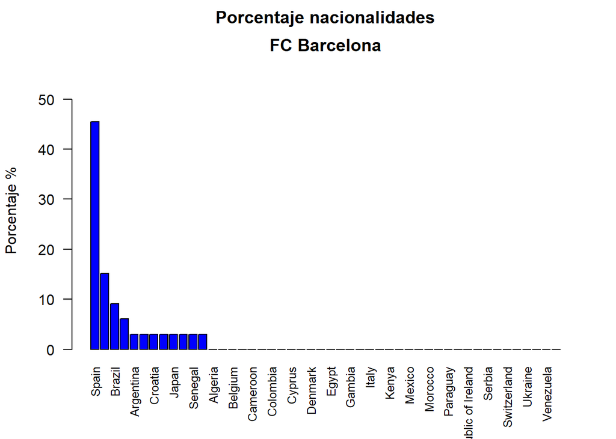

[figure not shown]

[figure not shown]

[figure not shown]

[figure not shown]

```r
for(i in 1:6){
  alturas=sort(porcen_nac_por_club[i,],decreasing=TRUE)
barplot(alturas,
        ylim=c(0,max(alturas)+10),
               las=2,cex.names=0.8,ylab="Porcentaje %",
        main=paste0(c("Porcentaje nacionalidades\n",nombre_club[i])),col="blue")
}
```

```r
# paste0  concatena  caracteres sin espacio, paste es la función general
```

## 1.9 Pregunta 8

Encuentra la función (lineal, exponencial o potencial) que mejor describe la dependencia funcional del sueldo de los jugadores en función de la variable `shooting` en el data frame `fifa20_best_shooting`. Representa dicha función junto con los puntos (shooting, sueldo) en escala lineal.

### 1.9.1 Solución

Hay que seguir los pasos de la lección [Un aperitivo: Introducción a la regresión linea: AprendeR1](https://aprender-uib.github.io/AprendeR1/chap-lm.html)

```r
tiro=fifa20_best_shooting$shooting
sueldo=fifa20_best_shooting$wage_eur
summary(lm(wage_eur~shooting,data=fifa20_best_shooting))$r.squared # lineal
```

```
## [1] 0.3338621
```

```r
summary(lm(log10(wage_eur)~log10(shooting),data=fifa20_best_shooting))$r.squared # potencial
```

```
## [1] 0.3137271
```

```r
summary(lm(log10(wage_eur)~shooting,data=fifa20_best_shooting))$r.squared # exponencial
```

```
## [1] 0.334811
```

El mejor modelo es el que tenga mejor $r.squared$ que es (por muy muy poco ) el exponencial

```r
lm(log10(wage_eur)~shooting,data=fifa20_best_shooting)
```

```
##
## Call:
## lm(formula = log10(wage_eur) ~ shooting, data = fifa20_best_shooting)
##
## Coefficients:
## (Intercept)     shooting
##     3.15960      0.02418
```

luego

$$\log_{10}(wage\_eur)= 0.02418 \cdot shooting + 3.15960.$$
$$wage\_eur= 10^{3.15960}\cdot 10^{0.02418\cdot shooting} .$$

Simplificando $10^{0.02418}\approx1.0573$ y $10^{0.02418}\approx1444.1091$. Luego el modelo exponencial es

$$wage\_eur= 1444.1091\cdot 1.0573^{shooting}.$$

Con estos datos podemos dibujar la gráfica con la curva y los datos

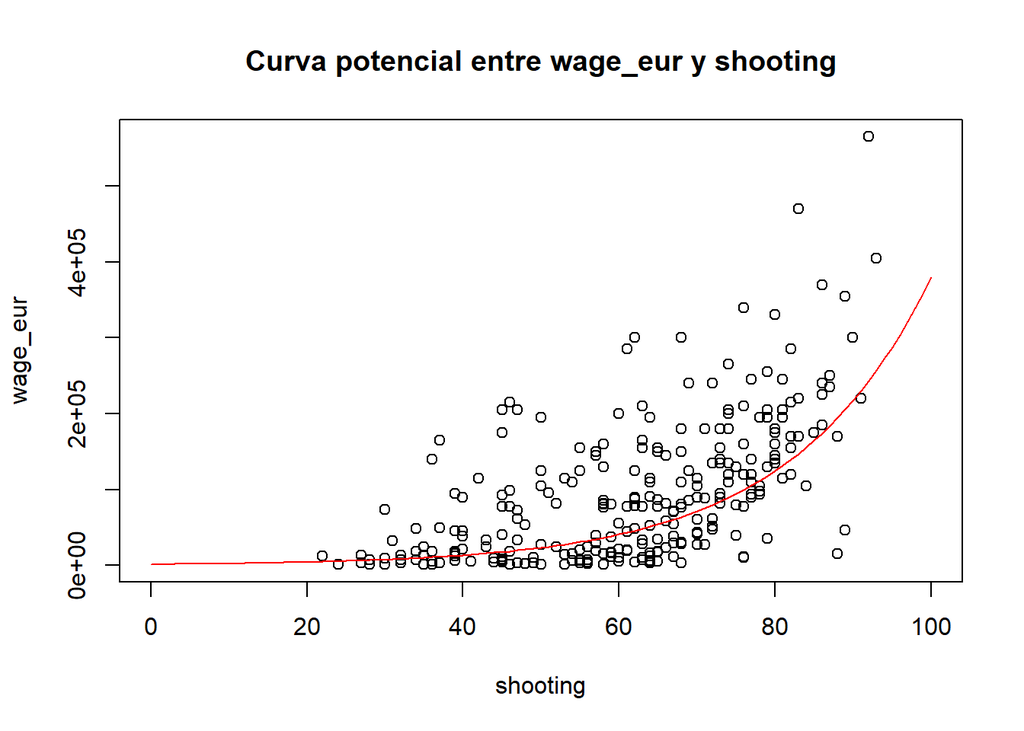

```r
potencial=function(x) {1444.1091* 1.0573^x}
plot(fifa20_best_shooting$shooting,fifa20_best_shooting$wage_eur,
     xlim=c(0,100),ylab="wage_eur",xlab="shooting",main="Curva potencial entre wage_eur y shooting")
curve(potencial(x),col="red",add = TRUE,xlim=c(0,100))
```